# Проверка гипотез по увеличению выручки в интернет-магазине — оценить результаты A/B теста

## Содержание

- Введение
- Часть 1. Приоритезация гипотез
  - Применение фреймворка ICE для приоритезации гипотез
  - Применение фреймворка RICE для приоритезации гипотез
  - Вывод
- Часть 2. Анализ A/B-теста
  - Предобработка данных
  - График кумулятивной выручки по группам
  - График кумулятивного среднего чека по группам
  - График относительного изменения кумулятивного среднего чека группы B к группе A
  - График кумулятивного среднего количества заказов на посетителя по группам
  - График относительного изменения кумулятивного среднего количества заказов на посетителя группы B к группе A
  - Точечный график количества заказов по пользователям
  - Точечный график стоимостей заказов
  - Расчёт статистической значимости
    - Расчёт статистической значимости различий в среднем количестве заказов на посетителя между группами по «сырым» данным
    - Расчёт статистической значимости различий в среднем чеке заказа между группами по «сырым» данным
    - Расчёт статистической значимости различий в среднем количестве заказов на посетителя между группами по «очищенным» данным
    - Расчёт статистической значимости различий в среднем чеке заказа между группами по «очищенным» данным
  - Вывод

## Введение

**Контекст**: я — аналитик крупного интернет-магазина. Вместе с отделом маркетинга я подготовила список гипотез для увеличения выручки.

**Цель проекта**: приоритизировать гипотезы, запустить A/B-тест и проанализировать результаты.

**Краткий план работы**: работа будет разбита на две части.

**Часть 1. Приоритизация гипотез**  
В файле `/datasets/hypothesis.csv` 9 гипотез по увеличению выручки интернет-магазина с указанными параметрами Reach, Impact, Confidence, Effort.

**Задачи:**

- поочерёдно применить фреймфорки ICE и RICE для приоритезации гипотез. Отсортировать гипотезы по убыванию приоритета.
- Объяснить изменение приоритетов гипотез при применении RICE вместо ICE.

**Часть 2. Анализ A/B-теста**  
После проведения A/B-теста были получены результаты, которые описаны в файлах `/datasets/orders.csv` и `/datasets/visitors.csv`.

**Задача:** проанализировать A/B-тест и принять решение по его результатам:  
а) Остановить тест, зафиксировать победу одной из групп.  
б) Остановить тест, зафиксировать отсутствие различий между группами.  
в) Продолжить тест.

## Часть 1. Приоритезация гипотез

### Применение фреймворка ICE для приоритезации гипотез

Импортируем все библиотеки, необходимые для исследования.

```python
import pandas as pd
pd.options.display.max_colwidth = 110
import numpy as np
import scipy.stats as stats
import datetime as dt
from matplotlib import pyplot as plt
```

Считаем .csv файл с данными о гипотезах в датафрейм:

`/datasets/hypothesis.csv` → `hypothesis`

```python
try:
    hypothesis = pd.read_csv('/datasets/hypothesis.csv')
except:
    hypothesis = pd.read_csv('https:/datasets/hypothesis.csv')

hypothesis.columns = hypothesis.columns.str.lower()
hypothesis
```

|  | hypothesis | reach | impact | confidence | efforts |
| --- | --- | --- | --- | --- | --- |
| 0 | Добавить два новых канала привлечения трафика, что позволит привлекать на 30% больше пользователей | 3 | 10 | 8 | 6 |
| 1 | Запустить собственную службу доставки, что сократит срок доставки заказов | 2 | 5 | 4 | 10 |
| 2 | Добавить блоки рекомендаций товаров на сайт интернет магазина, чтобы повысить конверсию и средний чек заказа | 8 | 3 | 7 | 3 |
| 3 | Изменить структура категорий, что увеличит конверсию, т.к. пользователи быстрее найдут нужный товар | 8 | 3 | 3 | 8 |
| 4 | Изменить цвет фона главной страницы, чтобы увеличить вовлеченность пользователей | 3 | 1 | 1 | 1 |
| 5 | Добавить страницу отзывов клиентов о магазине, что позволит увеличить количество заказов | 3 | 2 | 2 | 3 |
| 6 | Показать на главной странице баннеры с актуальными акциями и распродажами, чтобы увеличить конверсию | 5 | 3 | 8 | 3 |
| 7 | Добавить форму подписки на все основные страницы, чтобы собрать базу клиентов для email-рассылок | 10 | 7 | 8 | 5 |
| 8 | Запустить акцию, дающую скидку на товар в день рождения | 1 | 9 | 9 | 5 |

Проведём предобработку данных в датафрейме `hypothesis`:

```python
hypothesis.info()
```

```
<class 'pandas.core.frame.DataFrame'>
RangeIndex: 9 entries, 0 to 8
Data columns (total 5 columns):
 #   Column      Non-Null Count  Dtype
---  ------      --------------  -----
 0   hypothesis  9 non-null      object
 1   reach       9 non-null      int64
 2   impact      9 non-null      int64
 3   confidence  9 non-null      int64
 4   efforts     9 non-null      int64
dtypes: int64(4), object(1)
memory usage: 492.0+ bytes
```

В таблице отсутствуют пропущенные значения, значения заглушки, явные и неявные дубликаты. Типы данных корректные — датафрейм готов к анализу.

Рассчитаем приоритет гипотез с помощью фреймворка ICE. Воспользуемся формулой:

$ ICE\:SCORE = \large\frac{Impact\:\times\:Confidence}{Efforts}$

$Impact$ — насколько сильно изменение повлияет на пользователей, их опыт и удовлетворение от продукта;  
$Confidence$ — насколько уверены, что это изменение повлияет на пользователей именно так;  
$Efforts$ — сколько стоит протестировать эту гипотезу.

```python
hypothesis['ICE'] = round((hypothesis['impact']*hypothesis['confidence'])/hypothesis['efforts'],2)
hypothesis[['hypothesis','ICE']].sort_values(by='ICE', ascending=False)
```

|  | hypothesis | ICE |
| --- | --- | --- |
| 8 | Запустить акцию, дающую скидку на товар в день рождения | 16.20 |
| 0 | Добавить два новых канала привлечения трафика, что позволит привлекать на 30% больше пользователей | 13.33 |
| 7 | Добавить форму подписки на все основные страницы, чтобы собрать базу клиентов для email-рассылок | 11.20 |
| 6 | Показать на главной странице баннеры с актуальными акциями и распродажами, чтобы увеличить конверсию | 8.00 |
| 2 | Добавить блоки рекомендаций товаров на сайт интернет магазина, чтобы повысить конверсию и средний чек заказа | 7.00 |
| 1 | Запустить собственную службу доставки, что сократит срок доставки заказов | 2.00 |
| 5 | Добавить страницу отзывов клиентов о магазине, что позволит увеличить количество заказов | 1.33 |
| 3 | Изменить структура категорий, что увеличит конверсию, т.к. пользователи быстрее найдут нужный товар | 1.12 |
| 4 | Изменить цвет фона главной страницы, чтобы увеличить вовлеченность пользователей | 1.00 |

Наивысшим приоритетом обладают гипотезы *«Запустить акцию, дающую скидку на товар в день рождения»* (`ICE SCORE` — 16.2), *«Добавить два новых канала привлечения трафика, что позволит привлекать на 30% больше пользователей»* (`ICE SCORE` — 13.33) и *«Добавить форму подписки на все основные страницы, чтобы собрать базу клиентов для email-рассылок»* (`ICE SCORE` — 11.2).

### Применение фреймворка RICE для приоритезации гипотез

Произведём расчёт приоритета гипотез с помощью фреймворка RICE. Воспользуемся формулой:

$ RICE\:SCORE = \large\frac{Reach\:\times\:Impact\:\times\:Confidence}{Efforts}$

В формулу добавлен параметр $Reach$ — скольких пользователей затронет изменение;

```python
hypothesis['RICE'] = round((hypothesis['reach']*hypothesis['impact']*hypothesis['confidence'])/hypothesis['efforts'],2)
hypothesis[['hypothesis','reach','RICE']].sort_values(by='RICE', ascending=False)
```

|  | hypothesis | reach | RICE |
| --- | --- | --- | --- |
| 7 | Добавить форму подписки на все основные страницы, чтобы собрать базу клиентов для email-рассылок | 10 | 112.0 |
| 2 | Добавить блоки рекомендаций товаров на сайт интернет магазина, чтобы повысить конверсию и средний чек заказа | 8 | 56.0 |
| 0 | Добавить два новых канала привлечения трафика, что позволит привлекать на 30% больше пользователей | 3 | 40.0 |
| 6 | Показать на главной странице баннеры с актуальными акциями и распродажами, чтобы увеличить конверсию | 5 | 40.0 |
| 8 | Запустить акцию, дающую скидку на товар в день рождения | 1 | 16.2 |
| 3 | Изменить структура категорий, что увеличит конверсию, т.к. пользователи быстрее найдут нужный товар | 8 | 9.0 |
| 1 | Запустить собственную службу доставки, что сократит срок доставки заказов | 2 | 4.0 |
| 5 | Добавить страницу отзывов клиентов о магазине, что позволит увеличить количество заказов | 3 | 4.0 |
| 4 | Изменить цвет фона главной страницы, чтобы увеличить вовлеченность пользователей | 3 | 3.0 |

Наивысшим приоритетом обладают гипотезы *«Добавить форму подписки на все основные страницы, чтобы собрать базу клиентов для email-рассылок»* (`RICE SCORE` — 112) *«Добавить блоки рекомендаций товаров на сайт интернет магазина, чтобы повысить конверсию и средний чек заказа»* (`RICE SCORE` — 56), *«Добавить два новых канала привлечения трафика, что позволит привлекать на 30% больше пользователей»* и *Показать на главной странице баннеры с актуальными акциями и распродажами, чтобы увеличить конверсию* (`RICE SCORE` — 40).

### Вывод

Применение разных фреймворков дало разное распределение гипотез по величине приоритета. Согласно рассчитанным значениям ICE наивысшим приоритетом обладает гипотеза *«Запустить акцию, дающую скидку на товар в день рождения»*, при этом в рейтинге значений RICE эта же гипотеза находится на пятом месте. Это объясняется влиянием на оценку приоритета параметра $Reach$ — акцию, дающую скидку на товар в день рождения увидят только авторизованные пользователи, заполнившие в личном кабинете информацию о своём дне рождении, в то время как форму подписки на всех основных страницах (гипотеза с id 7) и блоки рекомендаций товаров (id 2) увидят практически все пользователи.

## Часть 2. Анализ A/B-теста

После проведения A/B-теста были получены результаты, описанные в файлах `/datasets/orders.csv` и `/datasets/visitors.csv`. Считаем данные в датафреймы:  
`/datasets/orders.csv` -> `orders`  
`/datasets/visitors.csv` -> `visitors`

### Предобработка данных

```python
try:
    orders = pd.read_csv('/datasets/orders.csv')
except:
    orders = pd.read_csv('https://datasets/orders.csv')

orders['date'] = orders['date'].map(
    lambda x: dt.datetime.strptime(x, '%Y-%m-%d')
)

orders.info()
orders.head()
```

```
<class 'pandas.core.frame.DataFrame'>
RangeIndex: 1197 entries, 0 to 1196
Data columns (total 5 columns):
 #   Column         Non-Null Count  Dtype
---  ------         --------------  -----
 0   transactionId  1197 non-null   int64
 1   visitorId      1197 non-null   int64
 2   date           1197 non-null   datetime64[ns]
 3   revenue        1197 non-null   int64
 4   group          1197 non-null   object
dtypes: datetime64[ns](1), int64(3), object(1)
memory usage: 46.9+ KB
```

|  | transactionId | visitorId | date | revenue | group |
| --- | --- | --- | --- | --- | --- |
| 0 | 3667963787 | 3312258926 | 2019-08-15 | 1650 | B |
| 1 | 2804400009 | 3642806036 | 2019-08-15 | 730 | B |
| 2 | 2961555356 | 4069496402 | 2019-08-15 | 400 | A |
| 3 | 3797467345 | 1196621759 | 2019-08-15 | 9759 | B |
| 4 | 2282983706 | 2322279887 | 2019-08-15 | 2308 | B |

Приведём названия столбцов `transactionId` и `visitorId` к змеиному регистру.

```python
orders = orders.rename(columns = {'transactionId':'transaction_id', 'visitorId':'visitor_id'})
orders
```

|  | transaction_id | visitor_id | date | revenue | group |
| --- | --- | --- | --- | --- | --- |
| 0 | 3667963787 | 3312258926 | 2019-08-15 | 1650 | B |
| 1 | 2804400009 | 3642806036 | 2019-08-15 | 730 | B |
| 2 | 2961555356 | 4069496402 | 2019-08-15 | 400 | A |
| 3 | 3797467345 | 1196621759 | 2019-08-15 | 9759 | B |
| 4 | 2282983706 | 2322279887 | 2019-08-15 | 2308 | B |
| ... | ... | ... | ... | ... | ... |
| 1192 | 2662137336 | 3733762160 | 2019-08-14 | 6490 | B |
| 1193 | 2203539145 | 370388673 | 2019-08-14 | 3190 | A |
| 1194 | 1807773912 | 573423106 | 2019-08-14 | 10550 | A |
| 1195 | 1947021204 | 1614305549 | 2019-08-14 | 100 | A |
| 1196 | 3936777065 | 2108080724 | 2019-08-15 | 202740 | B |

1197 rows × 5 columns

```python
print('Данные представлены с', orders['date'].min(), 'по', orders['date'].max())
```

```
Данные представлены с 2019-08-01 00:00:00 по 2019-08-31 00:00:00
```

```python
columns = orders.columns
for column in columns:
    print(column+":",orders[column].unique())
    print('\nКоличество уникальных значений в колонке '+column+':\n', orders.groupby(column)[column].count().sort_values(ascending=False))
    print('\nВсего уникальных в '+column+':', orders[column].nunique())
    print('\n')
```

```
transaction_id: [3667963787 2804400009 2961555356 ... 1807773912 1947021204 3936777065]

Количество уникальных значений в колонке transaction_id:
 transaction_id
1062393       1
2883105032    1
2875229767    1
2872509092    1
2866469834    1
             ..
1476831880    1
1476390797    1
1473132782    1
1472783002    1
4293855558    1
Name: transaction_id, Length: 1197, dtype: int64

Всего уникальных в transaction_id: 1197


visitor_id: [3312258926 3642806036 4069496402 ...  370388673  573423106 2108080724]

Количество уникальных значений в колонке visitor_id:
 visitor_id
4256040402    11
2458001652    11
2378935119     9
2038680547     8
199603092      5
              ..
1484903144     1
1485964287     1
1494664757     1
1495112755     1
4283872382     1
Name: visitor_id, Length: 1031, dtype: int64

Всего уникальных в visitor_id: 1031


```

[output cut: 145 more lines]

```
1294500     1
Name: revenue, Length: 713, dtype: int64

Всего уникальных в revenue: 713


group: ['B' 'A']

Количество уникальных значений в колонке group:
 group
B    640
A    557
Name: group, dtype: int64

Всего уникальных в group: 2
```

```python
print('Количество явных дубликатов:', orders.duplicated().sum())
```

```
Количество явных дубликатов: 0
```

**Вывод**: в датафрейме содержится информация о заказах совершённых покупателями с 1 по 31 августа 2019 года. Всего было создано 1197 заказов с уникальными идентификаторами. Явные дубликаты, пропущенные значения и значения-заглушки в датафрейме отсутствуют. Столбец `date` был приведён к типу данных `datetime64`, остальные столбцы в корректировке типа данных не нуждаются.

```python
try:
    visitors = pd.read_csv('/datasets/visitors.csv')
except:
    visitors = pd.read_csv('https://datasets/visitors.csv')

visitors['date'] = visitors['date'].map(
    lambda x: dt.datetime.strptime(x, '%Y-%m-%d')
)

visitors.info()
visitors.head()
```

```
<class 'pandas.core.frame.DataFrame'>
RangeIndex: 62 entries, 0 to 61
Data columns (total 3 columns):
 #   Column    Non-Null Count  Dtype
---  ------    --------------  -----
 0   date      62 non-null     datetime64[ns]
 1   group     62 non-null     object
 2   visitors  62 non-null     int64
dtypes: datetime64[ns](1), int64(1), object(1)
memory usage: 1.6+ KB
```

|  | date | group | visitors |
| --- | --- | --- | --- |
| 0 | 2019-08-01 | A | 719 |
| 1 | 2019-08-02 | A | 619 |
| 2 | 2019-08-03 | A | 507 |
| 3 | 2019-08-04 | A | 717 |
| 4 | 2019-08-05 | A | 756 |

```python
print('Даты проведения теста: с', visitors['date'].min(), 'по', visitors['date'].max())
```

```
Даты проведения теста: с 2019-08-01 00:00:00 по 2019-08-31 00:00:00
```

```python
columns = visitors.columns
for column in columns:
    print(column+':',visitors[column].unique())
    print('\nКоличество уникальных значений в колонке '+column+':\n', visitors.groupby(column)[column].count().sort_values(ascending=False))
    print('\nВсего уникальных в '+column+':', visitors[column].nunique())
    print('\n')
```

```
date: <DatetimeArray>
['2019-08-01 00:00:00', '2019-08-02 00:00:00', '2019-08-03 00:00:00',
 '2019-08-04 00:00:00', '2019-08-05 00:00:00', '2019-08-06 00:00:00',
 '2019-08-07 00:00:00', '2019-08-08 00:00:00', '2019-08-09 00:00:00',
 '2019-08-10 00:00:00', '2019-08-11 00:00:00', '2019-08-12 00:00:00',
 '2019-08-13 00:00:00', '2019-08-14 00:00:00', '2019-08-15 00:00:00',
 '2019-08-16 00:00:00', '2019-08-17 00:00:00', '2019-08-18 00:00:00',
 '2019-08-19 00:00:00', '2019-08-20 00:00:00', '2019-08-21 00:00:00',
 '2019-08-22 00:00:00', '2019-08-23 00:00:00', '2019-08-24 00:00:00',
 '2019-08-25 00:00:00', '2019-08-26 00:00:00', '2019-08-27 00:00:00',
 '2019-08-28 00:00:00', '2019-08-29 00:00:00', '2019-08-30 00:00:00',
 '2019-08-31 00:00:00']
Length: 31, dtype: datetime64[ns]

Количество уникальных значений в колонке date:
 date
2019-08-01    2
2019-08-17    2
2019-08-30    2
2019-08-29    2
2019-08-28    2
2019-08-27    2
2019-08-26    2
2019-08-25    2
2019-08-24    2
2019-08-23    2
2019-08-22    2
2019-08-21    2
2019-08-20    2
2019-08-19    2
2019-08-18    2
2019-08-16    2
2019-08-02    2
2019-08-15    2
2019-08-14    2
2019-08-13    2
2019-08-12    2
2019-08-11    2
2019-08-10    2
2019-08-09    2
```

[output cut: 76 more lines]

```
544    1
546    1
560    1
575    1
577    1
581    1
594    1
595    1
609    1
617    1
619    1
770    1
Name: visitors, dtype: int64

Всего уникальных в visitors: 58
```

```python
print('Количество явных дубликатов:', visitors.duplicated().sum())
```

```
Количество явных дубликатов: 0
```

В датафрейме `visitors` содержится 62 строки — по 31 записи для каждой тестируемой группы. Тест проводился с 1 по 31 августа 2019 года. В датафрейме отсутствуют явные дубликатыб пропущенные значения и значения-заглушки. Столбец `date` был приведён к типу данных `datetime64`, остальные столбцы в корректировке типа данных не нуждаются.

### График кумулятивной выручки по группам

```python
# создание массива уникальных пар значений дат и групп теста

datesGroups = orders[['date','group']].drop_duplicates()

# агрегированные кумулятивные по дням данные о заказах
ordersAggregated = datesGroups.apply(lambda x: orders[np.logical_and(orders['date'] <= x['date'], orders['group'] == x['group'])].agg({'date' : 'max', 'group' : 'max', 'transaction_id' : 'nunique', 'visitor_id' : 'nunique', 'revenue' : 'sum'}), axis=1).sort_values(by=['date','group'])

# агрегированные кумулятивные по дням данные о посетителях интернет-магазина
visitorsAggregated = datesGroups.apply(lambda x: visitors[np.logical_and(visitors['date'] <= x['date'], visitors['group'] == x['group'])].agg({'date' : 'max', 'group' : 'max', 'visitors' : 'sum'}), axis=1).sort_values(by=['date','group'])

# объединение кумулятивных данных в одной таблице
cumulativeData = ordersAggregated.merge(visitorsAggregated, left_on=['date', 'group'], right_on=['date', 'group'])
cumulativeData.columns = ['date', 'group', 'orders', 'buyers', 'revenue', 'visitors']

print(cumulativeData.head(5))
```

```
        date group  orders  buyers  revenue  visitors
0 2019-08-01     A      24      20   148579       719
1 2019-08-01     B      21      20   101217       713
2 2019-08-02     A      44      38   242401      1338
3 2019-08-02     B      45      43   266748      1294
4 2019-08-03     A      68      62   354874      1845
```

Построим графики кумулятивной выручки по дням и группам A/B-тестирования:

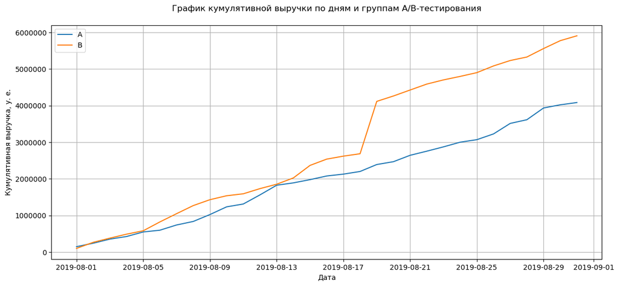

```python
# датафрейм с кумулятивным количеством заказов и кумулятивной выручкой по дням в группе B
cumulativeRevenueA = cumulativeData[cumulativeData['group']=='A'][['date','revenue', 'orders']]

# датафрейм с кумулятивным количеством заказов и кумулятивной выручкой по дням в группе B
cumulativeRevenueB = cumulativeData[cumulativeData['group']=='B'][['date','revenue', 'orders']]

plt.figure(figsize=(14,6))
plt.ticklabel_format(style='plain',axis='y')
# график выручки группы А
plt.plot(cumulativeRevenueA['date'], cumulativeRevenueA['revenue'], label='A')

# граафик выручки группы B
plt.plot(cumulativeRevenueB['date'], cumulativeRevenueB['revenue'], label='B')
plt.grid()
plt.legend()
plt.xlabel('Дата')
plt.ylabel('Кумулятивная выручка, у. е.')
plt.title('График кумулятивной выручки по дням и группам A/B-тестирования', pad='20.0');
```

**Вывод**: выручка почти равномерно увеличивалась для обоих групп теста до 18 августа, при этом кумулятивная выручка группы B выше, чем группы A. На графике кумулятивной выручки группы В хорошо заметен **скачок 19 августа** — причиной которого может быть **всплеск числа заказов или появление очень дорогих заказов в выборке**. После 19 числа выручка продолжила равномерно расти.

### График кумулятивного среднего чека по группам

Для построения графика кумулятивного среднего чека по группам — разделим кумлятивную выручку на кумулятивное число заказов.

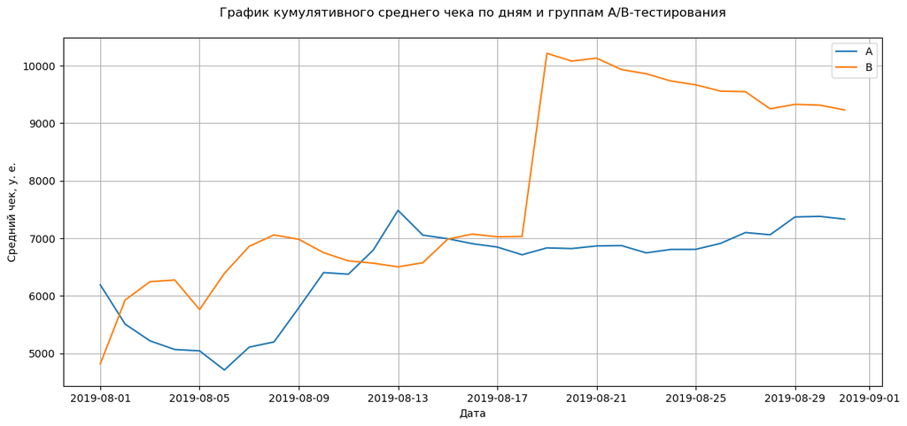

```python
plt.figure(figsize=(14,6))
plt.plot(cumulativeRevenueA['date'], cumulativeRevenueA['revenue']/cumulativeRevenueA['orders'], label='A')
plt.plot(cumulativeRevenueB['date'], cumulativeRevenueB['revenue']/cumulativeRevenueB['orders'], label='B')

plt.grid()
plt.legend()
plt.xlabel('Дата')
plt.ylabel('Средний чек, у. е.')
plt.title('График кумулятивного среднего чека по дням и группам A/B-тестирования', pad='20.0');
```

Кумулятивный средний чек группы B уступал значениям группы А только в первый день проведения теста и в период с 12 августа по 14 августа.

### График относительного изменения кумулятивного среднего чека группы B к группе A

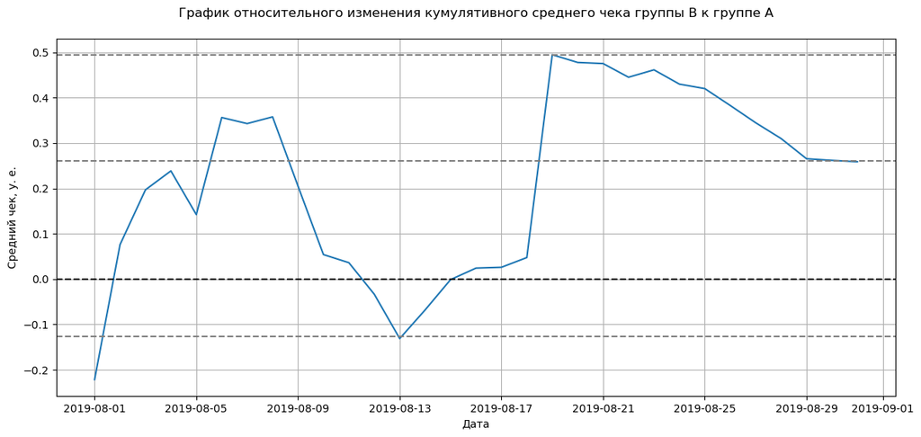

```python
mergedCumulativeRevenue = cumulativeRevenueA.merge(cumulativeRevenueB, left_on='date', right_on='date', how='left', suffixes=['A', 'B'])

# cтроим отношение средних чеков
plt.figure(figsize=(14,6))

plt.plot(mergedCumulativeRevenue['date'], (mergedCumulativeRevenue['revenueB']/mergedCumulativeRevenue['ordersB'])/(mergedCumulativeRevenue['revenueA']/mergedCumulativeRevenue['ordersA'])-1)

# добавляем ось X
plt.axhline(y=0, color='black', linestyle='--')

plt.grid()
plt.xlabel('Дата')
plt.ylabel('Средний чек, у. е.')
plt.title('График относительного изменения кумулятивного среднего чека группы B к группе A', pad='20.0')
plt.axhline(y=0.26, color='grey', linestyle='--')
plt.axhline(y=0.495, color='grey', linestyle='--')
plt.axhline(y=-0.127, color='grey', linestyle='--');
```

По аналогии с предыдущим графиком можем сделать вывод, что кумулятивное знаечние среднего чека группы А превышало значения группы B только в первый день тестирования и в перид с 12 по 14 августа. Максимальная разница мужду кумулятивными средними чеками была достигнута 19 августа: значение группы B превысило показатель А на 50%. Но и до крупного заказа средний чек группы B был выше: в период со 2 по 11 августа различие достигало 35%. Резкие подъемы и падения могут свидетельствовать о крупных заказах в группе B 6 B 19 августа, и в группе A 10 августа.

### График кумулятивного среднего количества заказов на посетителя по группам

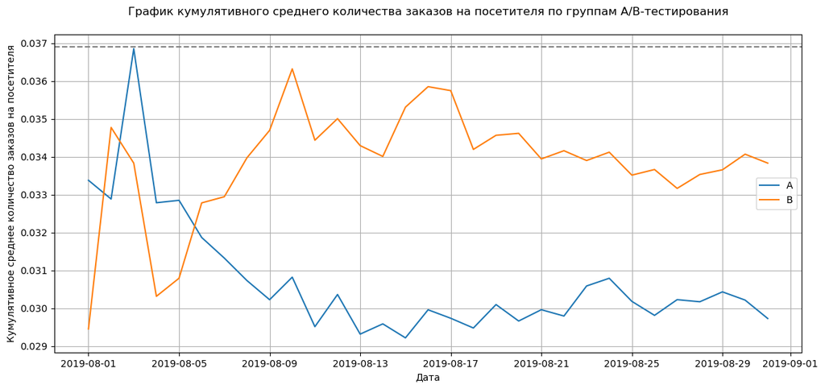

```python
# считаем среднее количество заказов на посетителя
cumulativeData['conversion'] = cumulativeData['orders']/cumulativeData['visitors']

# отделяем данные по группе A
cumulativeDataA = cumulativeData[cumulativeData['group']=='A']

# отделяем данные по группе B
cumulativeDataB = cumulativeData[cumulativeData['group']=='B']

# строим графики
plt.figure(figsize=(14,6))
plt.grid()

plt.xlabel('Дата')
plt.ylabel('Кумулятивное среднее количество заказов на посетителя')
plt.title('График кумулятивного среднего количества заказов на посетителя по группам A/B-тестирования', pad='20.0');

plt.plot(cumulativeDataA['date'], cumulativeDataA['conversion'], label='A')
plt.plot(cumulativeDataB['date'], cumulativeDataB['conversion'], label='B')
plt.axhline(y=0.0369, color='grey', linestyle='--')
plt.legend();
```

С момента начала тестирования и до 6 августа пользователи из группы А более охотно конвертировались в покупателей. Например 3 августа в этой группе количество заказов на одного посетителя достигло 3.69% — это максимальный показатель за все время тестирования). После 6 августа и до конца тестирования наоборот: посетители из группы B совершали больше заказов (в среднем на ~0.5%), но на графике заметна тенденция к снижению.

### График относительного изменения кумулятивного среднего количества заказов на посетителя группы B к группе A

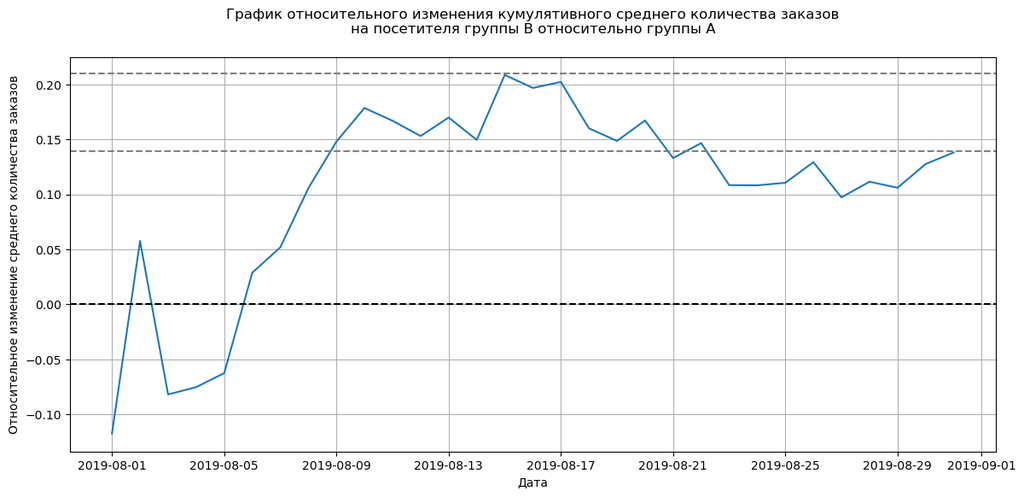

```python
mergedCumulativeConversions = cumulativeDataA[['date','conversion']].merge(cumulativeDataB[['date','conversion']], left_on='date', right_on='date', how='left', suffixes=['A', 'B'])

plt.figure(figsize=(14,6))

plt.ylabel('Относительное изменение среднего количества заказов')
plt.title('График относительного изменения кумулятивного среднего количества заказов\nна посетителя группы B относительно группы A', pad='20.0');

plt.xlabel('Дата')
plt.grid()
plt.plot(mergedCumulativeConversions['date'], mergedCumulativeConversions['conversionB']/mergedCumulativeConversions['conversionA']-1)


plt.axhline(y=0, color='black', linestyle='--')
plt.axhline(y=0.21, color='grey', linestyle='--')
plt.axhline(y=0.139, color='grey', linestyle='--');
```

Начиная с 6 августа группа B стабильно лучше группы А: в течение тестирования разрыв между группами достигал 21%. К концу тестирования среднее количество заказов на посетителя группы B опережало показатели группы А почти на 14%.

### Точечный график количества заказов по пользователям

```python
ordersByUsers = (
    orders.groupby('visitor_id', as_index=False)
    .agg({'transaction_id': 'nunique'})
)

ordersByUsers.columns = ['visitor_id', 'orders']
ordersByUsers.sort_values(by='orders', ascending=False).head(10)
```

|  | visitor_id | orders |
| --- | --- | --- |
| 1023 | 4256040402 | 11 |
| 591 | 2458001652 | 11 |
| 569 | 2378935119 | 9 |
| 487 | 2038680547 | 8 |
| 44 | 199603092 | 5 |
| 744 | 3062433592 | 5 |
| 55 | 237748145 | 5 |
| 917 | 3803269165 | 5 |
| 299 | 1230306981 | 5 |
| 897 | 3717692402 | 5 |

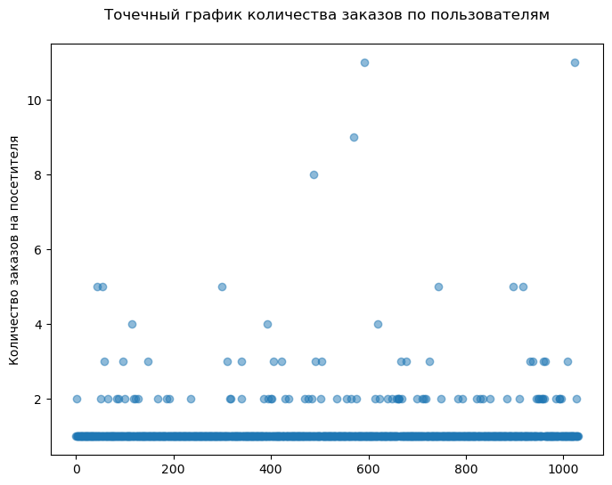

```python
x_values = pd.Series(range(0,len(ordersByUsers)))

plt.figure(figsize=(8,6))

plt.ylabel('Количество заказов на посетителя')
plt.title('Точечный график количества заказов по пользователям', pad='20.0');

plt.scatter(x_values, ordersByUsers['orders'], alpha=0.5);
```

Большинство покупателей совершали 1-2 заказа. Рассчитаем выборочные перцентили количества заказов на одного пользователя:

```python
print('95-й перцентиль количества заказов:', np.percentile(ordersByUsers['orders'], 95))
print('99-й перцентиль количества заказов:', np.percentile(ordersByUsers['orders'], 99))
```

```
95-й перцентиль количества заказов: 2.0
99-й перцентиль количества заказов: 4.0
```

Расчитаем промежуточные перцентили (96-й, 97-й, 98-й):

```python
print('96-й перцентиль количества заказов:', np.percentile(ordersByUsers['orders'], 96))
print('97-й перцентиль количества заказов:', np.percentile(ordersByUsers['orders'], 97))
print('98-й перцентиль количества заказов:', np.percentile(ordersByUsers['orders'], 98))
```

```
96-й перцентиль количества заказов: 2.0
97-й перцентиль количества заказов: 2.0
98-й перцентиль количества заказов: 3.0
```

### Точечный график стоимостей заказов

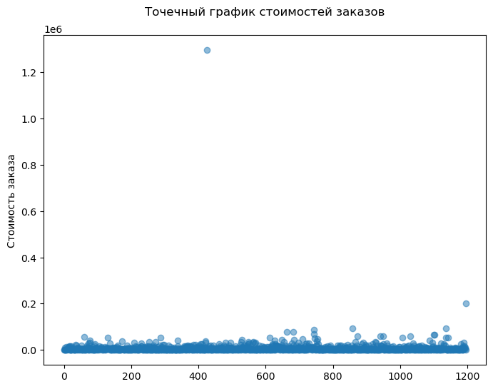

```python
x_values = pd.Series(range(0,len(orders['revenue'])))

plt.figure(figsize=(8,6))

plt.ylabel('Стоимость заказа')
plt.title('Точечный график стоимостей заказов', pad='20.0');
plt.scatter(x_values, orders['revenue'], alpha=0.5);
```

Из-за аномально крупного заказа на 1 294 500 у. е. остальные точки на графике скучены и сложночитаемы. Установим границы оси Y от 0 до 200 000 у. е.

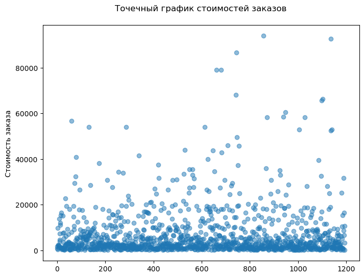

```python
x_values = pd.Series(range(0,len(orders.query('revenue<200000')['revenue'])))

plt.figure(figsize=(8,6))

plt.ylabel('Стоимость заказа')
plt.title('Точечный график стоимостей заказов', pad='20.0');
plt.scatter(x_values, orders.query('revenue<200000')['revenue'], alpha=0.5);
```

Основная масса заказов принесла до 20 000 у. е. выручки. Определим 95-й и 99-й перцентиль в выборке:

```python
print('95-й перцентиль среднего чека в выборке:', round(np.percentile(orders['revenue'], 95)))
print('99-й перцентиль среднего чека в выборке:', round(np.percentile(orders['revenue'], 99)))
```

```
95-й перцентиль среднего чека в выборке: 28000
99-й перцентиль среднего чека в выборке: 58233
```

Дополнительно рассчитаем промежуточные перцентили:

```python
print('96-й перцентиль среднего чека в выборке:', round(np.percentile(orders['revenue'], 96)))
print('97-й перцентиль среднего чека в выборке:', round(np.percentile(orders['revenue'], 97)))
print('98-й перцентиль среднего чека в выборке:', round(np.percentile(orders['revenue'], 98)))
```

```
96-й перцентиль среднего чека в выборке: 31382
97-й перцентиль среднего чека в выборке: 35485
98-й перцентиль среднего чека в выборке: 44133
```

Установим границу аномалий по 99-ому перцентилю (58233+ у. е.)

### Расчёт статистической значимости

Перед началом расчётов подготовим данные:

```python
visitorsADaily = visitors[visitors['group'] == 'A'][['date', 'visitors']]
visitorsADaily.columns = ['date', 'visitorsPerDateA']

visitorsACummulative = visitorsADaily.apply(
    lambda x: visitorsADaily[visitorsADaily['date'] <= x['date']].agg(
        {'date': 'max', 'visitorsPerDateA': 'sum'}
    ),
    axis=1,
)
visitorsACummulative.columns = ['date', 'visitorsCummulativeA']

visitorsBDaily = visitors[visitors['group'] == 'B'][['date', 'visitors']]
visitorsBDaily.columns = ['date', 'visitorsPerDateB']

visitorsBCummulative = visitorsBDaily.apply(
    lambda x: visitorsBDaily[visitorsBDaily['date'] <= x['date']].agg(
        {'date': 'max', 'visitorsPerDateB': 'sum'}
    ),
    axis=1,
)
visitorsBCummulative.columns = ['date', 'visitorsCummulativeB']

ordersADaily = (
    orders[orders['group'] == 'A'][['date', 'transaction_id', 'visitor_id', 'revenue']]
    .groupby('date', as_index=False)
    .agg({'transaction_id': pd.Series.nunique, 'revenue': 'sum'})
)
ordersADaily.columns = ['date', 'ordersPerDateA', 'revenuePerDateA']

ordersACummulative = ordersADaily.apply(
    lambda x: ordersADaily[ordersADaily['date'] <= x['date']].agg(
        {'date': 'max', 'ordersPerDateA': 'sum', 'revenuePerDateA': 'sum'}
    ),
    axis=1,
).sort_values(by=['date'])
ordersACummulative.columns = [
    'date',
    'ordersCummulativeA',
    'revenueCummulativeA',
]

ordersBDaily = (
    orders[orders['group'] == 'B'][['date', 'transaction_id', 'visitor_id', 'revenue']]
    .groupby('date', as_index=False)
    .agg({'transaction_id': pd.Series.nunique, 'revenue': 'sum'})
)
ordersBDaily.columns = ['date', 'ordersPerDateB', 'revenuePerDateB']

ordersBCummulative = ordersBDaily.apply(
    lambda x: ordersBDaily[ordersBDaily['date'] <= x['date']].agg(
        {'date': 'max', 'ordersPerDateB': 'sum', 'revenuePerDateB': 'sum'}
    ),
    axis=1,
).sort_values(by=['date'])
ordersBCummulative.columns = [
    'date',
    'ordersCummulativeB',
    'revenueCummulativeB',
]

data = (
    ordersADaily.merge(
        ordersBDaily, left_on='date', right_on='date', how='left'
    )
    .merge(ordersACummulative, left_on='date', right_on='date', how='left')
    .merge(ordersBCummulative, left_on='date', right_on='date', how='left')
    .merge(visitorsADaily, left_on='date', right_on='date', how='left')
    .merge(visitorsBDaily, left_on='date', right_on='date', how='left')
    .merge(visitorsACummulative, left_on='date', right_on='date', how='left')
    .merge(visitorsBCummulative, left_on='date', right_on='date', how='left')
)

print(data.head(5))
```

```
        date  ordersPerDateA  revenuePerDateA  ordersPerDateB  \
0 2019-08-01              24           148579              21
1 2019-08-02              20            93822              24
2 2019-08-03              24           112473              16
3 2019-08-04              16            70825              17
4 2019-08-05              25           124218              23

   revenuePerDateB  ordersCummulativeA  revenueCummulativeA  \
0           101217                  24               148579
1           165531                  44               242401
2           114248                  68               354874
3           108571                  84               425699
4            92428                 109               549917

   ordersCummulativeB  revenueCummulativeB  visitorsPerDateA  \
0                  21               101217               719
1                  45               266748               619
2                  61               380996               507
3                  78               489567               717
4                 101               581995               756

   visitorsPerDateB  visitorsCummulativeA  visitorsCummulativeB
0               713                   719                   713
1               581                  1338                  1294
2               509                  1845                  1803
3               770                  2562                  2573
4               707                  3318                  3280
```

- `date` — дата;
- `ordersPerDateA` — количество заказов в выбранную дату в группе A;
- `revenuePerDateA` — суммарная выручка в выбранную дату в группе A;
- `ordersPerDateB` — количество заказов в выбранную дату в группе B;
- `revenuePerDateB` — суммарная выручка в выбранную дату в группе B;
- `ordersCummulativeA` — суммарное число заказов до выбранной даты включительно в группе A;
- `revenueCummulativeA` — суммарная выручка до выбранной даты включительно в группе A;
- `ordersCummulativeB` — суммарное количество заказов до выбранной даты включительно в группе B;
- `revenueCummulativeB` — суммарная выручка до выбранной даты включительно в группе B;
- `visitorsPerDateA` — количество пользователей в выбранную дату в группе A;
- `visitorsPerDateB` — количество пользователей в выбранную дату в группе B;
- `visitorsCummulativeA` — количество пользователей до выбранной даты включительно в группе A;
- `visitorsCummulativeB` — количество пользователей до выбранной даты включительно в группе B.

#### Расчёт статистической значимости различий в среднем количестве заказов на посетителя между группами по «сырым» данным

Сформулируем гипотезы:  
$H_0$: различий в среднем количестве заказов на посетителя между группами нет.  
$H_1$: различия в среднем количестве заказов на посетителя между группами есть.

Создадим переменные `ordersByUsersA` и `ordersByUsersB` со столбцами `['user_id', 'orders']`. В них для пользователей, которые заказывали хотя бы 1 раз, укажем число совершённых заказов.

```python
ordersByUsersA = (
    orders[orders['group'] == 'A']
    .groupby('visitor_id', as_index=False)
    .agg({'transaction_id': pd.Series.nunique})
)
ordersByUsersA.columns = ['user_id', 'orders']

ordersByUsersB = (
    orders[orders['group'] == 'B']
    .groupby('visitor_id', as_index=False)
    .agg({'transaction_id': pd.Series.nunique})
)
ordersByUsersB.columns = ['user_id', 'orders']
```

Объявим переменные `sampleA` и `sampleB`, в которых пользователям из разных групп будет соответствовать количество заказов. Тем, кто ничего не заказал, будут соответствовать нули.

```python
sampleA = pd.concat(
    [
        ordersByUsersA['orders'],
        pd.Series(
            0,
            index=np.arange(
                data['visitorsPerDateA'].sum() - len(ordersByUsersA['orders'])
            ),
            name='orders',
        ),
    ],
    axis=0,
)
sampleB = pd.concat(
    [
        ordersByUsersB['orders'],
        pd.Series(
            0,
            index=np.arange(
                data['visitorsPerDateB'].sum() - len(ordersByUsersB['orders'])
            ),
            name='orders',
        ),
    ],
    axis=0,
)
```

Применим U-критерий Манна-Уитни и отформатируем *p-value*, округлив его до трёх знаков после запятой.

```python
print('alpha =',0.05)
print('p-value:', '{0:.3f}'.format(stats.mannwhitneyu(sampleA, sampleB)[1]))
print('Относительный прирост среднего числа заказов группы B:','{0:.2f}%'.format((sampleB.mean() / sampleA.mean() - 1)*100))
```

```
alpha = 0.05
p-value: 0.017
Относительный прирост среднего числа заказов группы B: 13.81%
```

#### Расчёт статистической значимости различий в среднем чеке заказа между группами по «сырым» данным

Сформулируем гипотезы:  
$H_0$: различий в среднем чеке между группами нет.  
$H_1$: различия в среднем чеке между группами есть.

Для расчёта статистической значимости различий в среднем чеке передадим критерию `mannwhitneyu()` данные о выручке с заказов.

```python
print('alpha =',0.05)
print('p-value:','{0:.3f}'.format(stats.mannwhitneyu(orders[orders['group']=='A']['revenue'], orders[orders['group']=='B']['revenue'])[1]))
print('Относительные различия в среднем чеке между группами:','{0:.2f}%'.format((orders[orders['group']=='B']['revenue'].mean()/orders[orders['group']=='A']['revenue'].mean() - 1)*100))
```

```
alpha = 0.05
p-value: 0.729
Относительные различия в среднем чеке между группами: 25.87%
```

**Вывод**: р-value значительно превышает уровень статистической значимости ($\alpha$ = 0.05). Причин отвергать нулевую гипотезу и считать, что в среднем чеке есть различия, нет. Однако, согласно расчётам, относительное различие в среднем чеке между группами составляет 25.87%.

#### Расчёт статистической значимости различий в среднем количестве заказов на посетителя между группами по «очищенным» данным

Выше определили критерии аномального пользователя: «совершено более двух заказов», «сумма заказа превышкает 58 233 у. е.». Отсечём пользователей, подпавших под эти критерии и определем их количество:

```python
usersWithManyOrders = pd.concat(
    [
        ordersByUsersA[ordersByUsersA['orders'] > 2]['user_id'],
        ordersByUsersB[ordersByUsersB['orders'] > 2]['user_id'],
    ],
    axis=0,
)
usersWithExpensiveOrders = orders[orders['revenue'] > 58233]['visitor_id']
abnormalUsers = (
    pd.concat([usersWithManyOrders, usersWithExpensiveOrders], axis=0)
    .drop_duplicates()
    .sort_values()
)
print(abnormalUsers.head(5))
print('Количество аномальных пользователей:', abnormalUsers.shape[0])
```

```
1099    148427295
18      199603092
23      237748145
37      249864742
68      457167155
dtype: int64
Количество аномальных пользователей: 31
```

На этапе исследовательского анализа узнали, что всего уникальных пользователей 1031. Доля аномальных пользователей составила 3%. Отфильтруем выборки от аномалий:

```python
sampleAFiltered = pd.concat(
    [
        ordersByUsersA[
            np.logical_not(ordersByUsersA['user_id'].isin(abnormalUsers))
        ]['orders'],
        pd.Series(
            0,
            index=np.arange(
                data['visitorsPerDateA'].sum() - len(ordersByUsersA['orders'])
            ),
            name='orders',
        ),
    ],
    axis=0,
)

sampleBFiltered = pd.concat(
    [
        ordersByUsersB[
            np.logical_not(ordersByUsersB['user_id'].isin(abnormalUsers))
        ]['orders'],
        pd.Series(
            0,
            index=np.arange(
                data['visitorsPerDateB'].sum() - len(ordersByUsersB['orders'])
            ),
            name='orders',
        ),
    ],
    axis=0,
)
```

```python
print('alpha =',0.05)
print('p-value:','{0:.3f}'.format(stats.mannwhitneyu(sampleAFiltered, sampleBFiltered)[1]))
print('Относительный прирост среднего числа заказов группы B:','{0:.2f}%'.format((sampleBFiltered.mean()/sampleAFiltered.mean()- 1)*100))
```

```
alpha = 0.05
p-value: 0.010
Относительный прирост среднего числа заказов группы B: 17.43%
```

#### Расчёт статистической значимости различий в среднем чеке заказа между группами по «очищенным» данным

```python
print('alpha =',0.05)

print(
    'p-value:', '{0:.3f}'.format(
        stats.mannwhitneyu(
            orders[
                np.logical_and(
                    orders['group'] == 'A',
                    np.logical_not(orders['visitor_id'].isin(abnormalUsers)),
                )
            ]['revenue'],
            orders[
                np.logical_and(
                    orders['group'] == 'B',
                    np.logical_not(orders['visitor_id'].isin(abnormalUsers)),
                )
            ]['revenue'],
        )[1]
    )
)

print(
    'Относительные различия в среднем чеке между группами:','{0:.2f}%'.format((
        orders[
            np.logical_and(
                orders['group'] == 'B',
                np.logical_not(orders['visitor_id'].isin(abnormalUsers)),
            )
        ]['revenue'].mean()
        / orders[
            np.logical_and(
                orders['group'] == 'A',
                np.logical_not(orders['visitor_id'].isin(abnormalUsers)),
            )
        ]['revenue'].mean()
        - 1)*100
    )
)
```

```
alpha = 0.05
p-value: 0.798
Относительные различия в среднем чеке между группами: -2.00%
```

**Вывод**: р-value значительно превышает уровень статистической значимости ($\alpha$ = 0.05). Причин отвергать нулевую гипотезу и считать, что в среднем чеке есть различия, нет. После удаления аномальных данных из выборки средний чек группы B оказался ниже среднего чека группы А на 2% (напомним, что до очистки данных он было больше на 26%).

### Вывод

1. Существует статистически значимое различие по среднему количеству заказов между группами: по «сырым» данным относительный прирост среднего числа заказов группы B составил 13.81%, а по «очищенным» — 17.43%.
2. Нет статистически значимого различия по среднему чеку между граппами ни по «сырым», ни по данным после фильтрацииб не смотря на то что до очистки от аномальных пользователей относительные различия в среднем чеке между группами составляли 25.87%. После фильтрации средние чеки обеих групп почти сравнялись (разница сотавляет 2% в пользу группы A).
3. Согласно графику различия конверсии между группами: результаты группы B гораздо лучше группы А.
4. График различия среднего чека колеблется, из него сделали выводы, что в выборке присутствуют аномально крупные заказы.

Исходя из обнаруженных фактов, тест следует остановить и **зафиксровать победу группы B**, несмотря на небольшую разницу в средних чеках мужду группами, посетители из B более охотно конвертировались в покупателей.